# BA Project (Titanic)

```python
from IPython.display import Image
Image(url= "https://static1.squarespace.com/static/5006453fe4b09ef2252ba068/5095eabce4b06cb305058603/5095eabce4b02d37bef4c24c/1352002236895/100_anniversary_titanic_sinking_by_esai8mellows-d4xbme8.jpg")
```

[figure not shown]

## 1. Import Data & Python Packages

```python
import pandas as pd
import numpy as np
from sklearn import preprocessing
import matplotlib.pyplot as plt
plt.rc("font", size=14)
import seaborn as sns
sns.set(style="white") #white background style for seaborn plots
sns.set(style="whitegrid", color_codes=True)
```

```python
titanic_df = pd.read_csv("C:\\Program Files\\R\\train.csv")
```

```python
titanic_df.head(5)
```

|  | PassengerId | Survived | Pclass | Name | Sex | Age | SibSp | Parch | Ticket | Fare | Cabin | Embarked |
| --- | --- | --- | --- | --- | --- | --- | --- | --- | --- | --- | --- | --- |
| 0 | 1 | 0 | 3 | Braund, Mr. Owen Harris | male | 22.0 | 1 | 0 | A/5 21171 | 7.2500 | NaN | S |
| 1 | 2 | 1 | 1 | Cumings, Mrs. John Bradley (Florence Briggs Th... | female | 38.0 | 1 | 0 | PC 17599 | 71.2833 | C85 | C |
| 2 | 3 | 1 | 3 | Heikkinen, Miss. Laina | female | 26.0 | 0 | 0 | STON/O2. 3101282 | 7.9250 | NaN | S |
| 3 | 4 | 1 | 1 | Futrelle, Mrs. Jacques Heath (Lily May Peel) | female | 35.0 | 1 | 0 | 113803 | 53.1000 | C123 | S |
| 4 | 5 | 0 | 3 | Allen, Mr. William Henry | male | 35.0 | 0 | 0 | 373450 | 8.0500 | NaN | S |

## 2. Data Quality & Missing Value Assessment

```python
titanic_df.isnull().sum()
```

```
PassengerId      0
Survived         0
Pclass           0
Name             0
Sex              0
Age            177
SibSp            0
Parch            0
Ticket           0
Fare             0
Cabin          687
Embarked         2
dtype: int64
```

#### 2.1 Age - Missing Values

```python
sum(pd.isnull(titanic_df['Age']))
```

```
177
```

```python
# proportion of "Age" missing
round(177/(len(titanic_df["PassengerId"])),4)
```

```
0.1987
```

~20% of entries for passenger age are missing. Let's see what the 'Age' variable looks like in general.

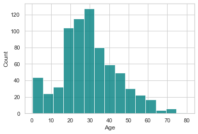

```python
ax = titanic_df["Age"].hist(bins=15, color='teal', alpha=0.8)
ax.set(xlabel='Age', ylabel='Count')
plt.show()
```

Since "Age" is (right) skewed, using the mean might give us biased results by filling in ages that are older than desired. To deal with this, we'll use the median to impute the missing values.

```python
# median age is 28 (as compared to mean which is ~30)
titanic_df["Age"].median(skipna=True)
```

```
28.0
```

#### 2.2 Cabin - Missing Values

```python
# proportion of "cabin" missing
round(687/len(titanic_df["PassengerId"]),4)
```

```
0.771
```

77% of records are missing, which means that imputing information and using this variable for prediction is probably not wise. We'll ignore this variable in our model.

#### 2.3 Embarked - Missing Values

```python
# proportion of "Embarked" missing
round(2/len(titanic_df["PassengerId"]),4)
```

```
0.0022
```

There are only 2 missing values for "Embarked", so we can just impute with the port where most people boarded.

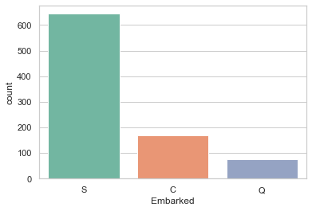

```python
sns.countplot(x='Embarked',data=titanic_df,palette='Set2')
plt.show()
```

#### 2.4 Final Adjustments to Data (Train & Test)

```python
train_data = titanic_df
train_data["Age"].fillna(28, inplace=True)
train_data["Embarked"].fillna("S", inplace=True)
train_data.drop('Cabin', axis=1, inplace=True)
```

#### 2.4.1 Additional Variables

```python
## Create categorical variable for traveling alone

train_data['TravelBuds']=train_data["SibSp"]+train_data["Parch"]
train_data['TravelAlone']=np.where(train_data['TravelBuds']>0, 0, 1)
```

```python
train_data.drop('SibSp', axis=1, inplace=True)
train_data.drop('Parch', axis=1, inplace=True)
train_data.drop('TravelBuds', axis=1, inplace=True)
```

```python
#create categorical variable for Pclass

train2 = pd.get_dummies(train_data, columns=["Pclass"])
```

```python
train3 = pd.get_dummies(train2, columns=["Embarked"])
train4=pd.get_dummies(train3, columns=["Sex"])
```

```python
train4.drop('Sex_female', axis=1, inplace=True)
```

```python
train4.drop('PassengerId', axis=1, inplace=True)
train4.drop('Name', axis=1, inplace=True)
train4.drop('Ticket', axis=1, inplace=True)
train4.head(5)
```

|  | Survived | Age | Fare | TravelAlone | Pclass_1 | Pclass_2 | Pclass_3 | Embarked_C | Embarked_Q | Embarked_S | Sex_male |
| --- | --- | --- | --- | --- | --- | --- | --- | --- | --- | --- | --- |
| 0 | 0 | 22.0 | 7.2500 | 0 | 0 | 0 | 1 | 0 | 0 | 1 | 1 |
| 1 | 1 | 38.0 | 71.2833 | 0 | 1 | 0 | 0 | 1 | 0 | 0 | 0 |
| 2 | 1 | 26.0 | 7.9250 | 1 | 0 | 0 | 1 | 0 | 0 | 1 | 0 |
| 3 | 1 | 35.0 | 53.1000 | 0 | 1 | 0 | 0 | 0 | 0 | 1 | 0 |
| 4 | 0 | 35.0 | 8.0500 | 1 | 0 | 0 | 1 | 0 | 0 | 1 | 1 |

```python
df_final = train4
```

### 3. Exploratory Data Analysis

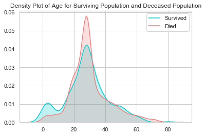

```python
sns.kdeplot(titanic_df["Age"][df_final.Survived == 1], color="darkturquoise", shade=True)
sns.kdeplot(titanic_df["Age"][df_final.Survived == 0], color="lightcoral", shade=True)
plt.legend(['Survived', 'Died'])
plt.title('Density Plot of Age for Surviving Population and Deceased Population')
plt.show()
```

The age distribution for survivors and deceased is actually very similar. One notable difference is that, of the survivors, a larger proportion were children. The passengers evidently made an attempt to save children by giving them a place on the life rafts.

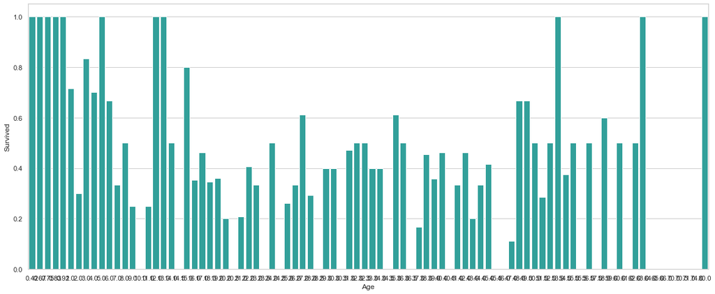

```python
plt.figure(figsize=(20,8))
avg_survival_byage = df_final[["Age", "Survived"]].groupby(['Age'],as_index=False).mean()
g = sns.barplot(x='Age', y='Survived', data=avg_survival_byage, color="LightSeaGreen")
```

Considering the survival rate of passengers under 16, I'll also include another categorical variable in my dataset: "Minor"

```python
df_final['IsMinor']=np.where(train_data['Age']<=16, 1, 0)
```

### 3.2 Exploration of Fare

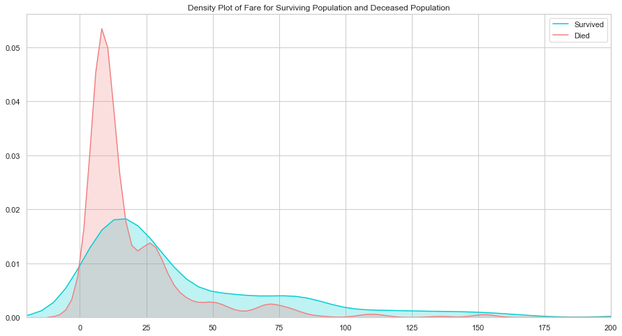

```python
plt.figure(figsize=(15,8))
sns.kdeplot(df_final["Fare"][titanic_df.Survived == 1], color="darkturquoise", shade=True)
sns.kdeplot(df_final["Fare"][titanic_df.Survived == 0], color="lightcoral", shade=True)
plt.legend(['Survived', 'Died'])
plt.title('Density Plot of Fare for Surviving Population and Deceased Population')
# limit x axis to zoom on most information. there are a few outliers in fare.
plt.xlim(-20,200)
plt.show()
```

As the distributions are clearly different for the fares of survivors vs. deceased, it's likely that this would be a significant predictor in our final model. Passengers who paid lower fare appear to have been less likely to survive. This is probably strongly correlated with Passenger Class, which we'll look at next.

### 3.3 Exploration of Passenger Class

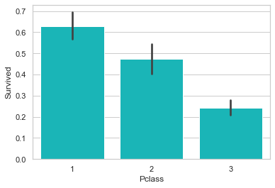

```python
sns.barplot('Pclass', 'Survived', data=titanic_df, color="darkturquoise")
plt.show()
```

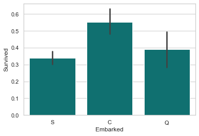

```python
sns.barplot('Embarked', 'Survived', data=titanic_df, color="teal")
plt.show()
```

Passengers who boarded in Cherbourg, France, appear to have the highest survival rate. Passengers who boarded in Southhampton were marginally less likely to survive than those who boarded in Queenstown. This is probably related to passenger class, or maybe even the order of room assignments (e.g. maybe earlier passengers were more likely to have rooms closer to deck). It's also worth noting the size of the whiskers in these plots. Because the number of passengers who boarded at Southhampton was highest, the confidence around the survival rate is the highest. The whisker of the Queenstown plot includes the Southhampton average, as well as the lower bound of its whisker. It's possible that Queenstown passengers were equally, or even more, ill-fated than their Southhampton counterparts.

### 3.5 Exploration of Traveling Alone vs. With Family

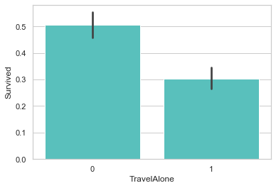

```python
sns.barplot('TravelAlone', 'Survived', data=df_final, color="mediumturquoise")
plt.show()
```

Individuals traveling without family were more likely to die in the disaster than those with family aboard. Given the era, it's likely that individuals traveling alone were likely male.

### 3.6 Exploration of Gender Variable

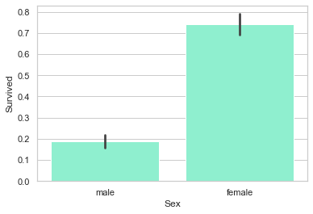

```python
sns.barplot('Sex', 'Survived', data=titanic_df, color="aquamarine")
plt.show()
```

This is a very obvious difference. Clearly being female greatly increased your chances of survival.\

### 4. Logistic Regression and Results

```python
df_final.head(10)
```

|  | Survived | Age | Fare | TravelAlone | Pclass_1 | Pclass_2 | Pclass_3 | Embarked_C | Embarked_Q | Embarked_S | Sex_male | IsMinor |
| --- | --- | --- | --- | --- | --- | --- | --- | --- | --- | --- | --- | --- |
| 0 | 0 | 22.0 | 7.2500 | 0 | 0 | 0 | 1 | 0 | 0 | 1 | 1 | 0 |
| 1 | 1 | 38.0 | 71.2833 | 0 | 1 | 0 | 0 | 1 | 0 | 0 | 0 | 0 |
| 2 | 1 | 26.0 | 7.9250 | 1 | 0 | 0 | 1 | 0 | 0 | 1 | 0 | 0 |
| 3 | 1 | 35.0 | 53.1000 | 0 | 1 | 0 | 0 | 0 | 0 | 1 | 0 | 0 |
| 4 | 0 | 35.0 | 8.0500 | 1 | 0 | 0 | 1 | 0 | 0 | 1 | 1 | 0 |
| 5 | 0 | 28.0 | 8.4583 | 1 | 0 | 0 | 1 | 0 | 1 | 0 | 1 | 0 |
| 6 | 0 | 54.0 | 51.8625 | 1 | 1 | 0 | 0 | 0 | 0 | 1 | 1 | 0 |
| 7 | 0 | 2.0 | 21.0750 | 0 | 0 | 0 | 1 | 0 | 0 | 1 | 1 | 1 |
| 8 | 1 | 27.0 | 11.1333 | 0 | 0 | 0 | 1 | 0 | 0 | 1 | 0 | 0 |
| 9 | 1 | 14.0 | 30.0708 | 0 | 0 | 1 | 0 | 1 | 0 | 0 | 0 | 1 |

```python
cols=["Age", "Fare", "TravelAlone", "Pclass_1", "Pclass_2","Embarked_C","Embarked_S","Sex_male","IsMinor"]
X=df_final[cols]
Y=df_final['Survived']
```

```python
import statsmodels.api as sm
from scipy import stats
stats.chisqprob = lambda chisq, df: stats.chi2.sf(chisq, df)
logit_model=sm.Logit(Y,X)
result=logit_model.fit()
print(result.summary())
```

```
Optimization terminated successfully.
         Current function value: 0.450348
         Iterations 6
                           Logit Regression Results
==============================================================================
Dep. Variable:               Survived   No. Observations:                  891
Model:                          Logit   Df Residuals:                      882
Method:                           MLE   Df Model:                            8
Date:                Thu, 19 Mar 2020   Pseudo R-squ.:                  0.3237
Time:                        19:49:24   Log-Likelihood:                -401.26
converged:                       True   LL-Null:                       -593.33
Covariance Type:            nonrobust   LLR p-value:                 4.627e-78
===============================================================================
                  coef    std err          z      P>|z|      [0.025      0.975]
-------------------------------------------------------------------------------
Age            -0.0096      0.007     -1.372      0.170      -0.023       0.004
Fare            0.0018      0.002      0.807      0.420      -0.003       0.006
TravelAlone     0.3520      0.193      1.828      0.068      -0.025       0.729
Pclass_1        2.0491      0.276      7.424      0.000       1.508       2.590
Pclass_2        1.2940      0.231      5.593      0.000       0.841       1.747
Embarked_C      0.5627      0.317      1.778      0.075      -0.058       1.183
Embarked_S      0.0093      0.256      0.036      0.971      -0.492       0.511
Sex_male       -2.5915      0.200    -12.979      0.000      -2.983      -2.200
IsMinor         1.0566      0.311      3.402      0.001       0.448       1.665
===============================================================================
```

```python
cols2=["Age", "Pclass_1", "Pclass_2","Embarked_C","Embarked_S","Sex_male"]
X2=df_final[cols2]
Y=df_final['Survived']

logit_model=sm.Logit(Y,X2)
result=logit_model.fit()

print(result.summary())
```

```
Optimization terminated successfully.
         Current function value: 0.458585
         Iterations 6
                           Logit Regression Results
==============================================================================
Dep. Variable:               Survived   No. Observations:                  891
Model:                          Logit   Df Residuals:                      885
Method:                           MLE   Df Model:                            5
Date:                Thu, 19 Mar 2020   Pseudo R-squ.:                  0.3113
Time:                        19:49:25   Log-Likelihood:                -408.60
converged:                       True   LL-Null:                       -593.33
Covariance Type:            nonrobust   LLR p-value:                 1.131e-77
==============================================================================
                 coef    std err          z      P>|z|      [0.025      0.975]
------------------------------------------------------------------------------
Age           -0.0158      0.006     -2.602      0.009      -0.028      -0.004
Pclass_1       2.0449      0.238      8.604      0.000       1.579       2.511
Pclass_2       1.2598      0.226      5.564      0.000       0.816       1.704
Embarked_C     1.0698      0.279      3.836      0.000       0.523       1.616
Embarked_S     0.5129      0.218      2.350      0.019       0.085       0.941
Sex_male      -2.4625      0.187    -13.194      0.000      -2.828      -2.097
==============================================================================
```

```python
from sklearn.linear_model import LogisticRegression

logreg = LogisticRegression()
logreg.fit(X2, Y)

logreg.score(X2, Y)
```

[output not shown]

```
0.7934904601571269
```

## Model's Predictive Score: 0.7935

#### 4.3 Using 80-20 Split for Cross Validation

```python
from sklearn.model_selection import train_test_split
train, test = train_test_split(df_final, test_size=0.2)
```

```python
#re-fit logistic regression on new train sample

cols2=["Age", "Pclass_1", "Pclass_2","Embarked_C","Embarked_S","Sex_male"]
X3=train[cols2]
Y3=train['Survived']
logit_model3=sm.Logit(Y3,X3)
```

```python
from sklearn.linear_model import LogisticRegression
from sklearn import metrics

logreg = LogisticRegression()
logreg.fit(X3, Y3)
logreg.score(X3, Y3)
```

[output not shown]

```
0.797752808988764
```

The score for the new training sample (80% of original) is very close to the original performance, which is good! Let's assess how well it scores on the 20% hold-out sample.

```python
from sklearn import metrics
logreg.fit(X3, Y3)

X3_test = test[cols2]
Y3_test = test['Survived']

Y3test_pred = logreg.predict(X3_test)
print('Accuracy of logistic regression classifier on test set: {:.2f}'.format(logreg.score(X3_test, Y3_test)))
```

```
Accuracy of logistic regression classifier on test set: 0.77
```

[output not shown]

### 4.4 Out-of-sample Assessment

```python
# Model's in sample AUC

from sklearn.metrics import roc_auc_score
logreg.fit(X3, Y3)
Y3_pred = logreg.predict(X3)

y_true = Y3
y_scores = Y3_pred
roc_auc_score(y_true, y_scores)
```

[output not shown]

```
0.7786338042415455
```

[output not shown]

```
ROC AUC: 0.839
```

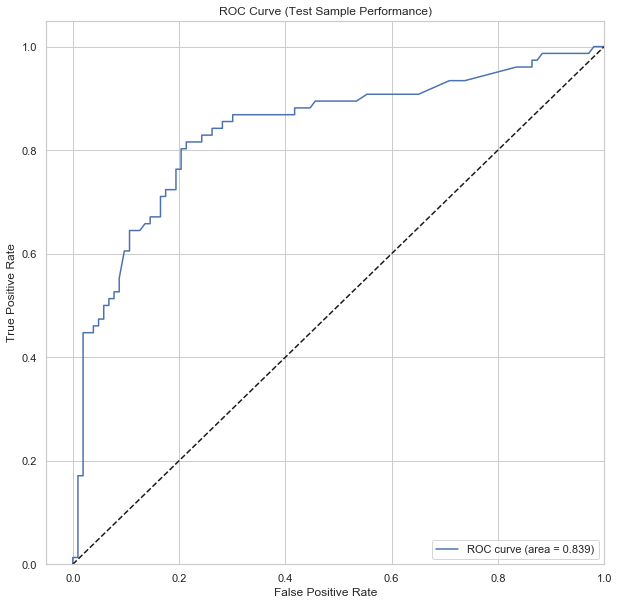

```python
#Visualizing the model's ROC curve (**source for graph code given below the plot)
from sklearn.metrics import roc_curve, auc
logreg.fit(X3, Y3)

y_test = Y3_test
X_test = X3_test

# Determine the false positive and true positive rates
FPR, TPR, _ = roc_curve(y_test, logreg.predict_proba(X_test)[:,1])

# Calculate the AUC

roc_auc = auc(FPR, TPR)
print ('ROC AUC: %0.3f' % roc_auc )

# Plot of a ROC curve
plt.figure(figsize=(10,10))
plt.plot(FPR, TPR, label='ROC curve (area = %0.3f)' % roc_auc)
plt.plot([0, 1], [0, 1], 'k--')
plt.xlim([-0.05, 1.0])
plt.ylim([0.0, 1.05])
plt.xlabel('False Positive Rate')
plt.ylabel('True Positive Rate')
plt.title('ROC Curve (Test Sample Performance)')
plt.legend(loc="lower right")
plt.show()
```

An AUC score of 0.5 is effectively as good as the flip of a coin, and means that the model really has no classification power at all between the positive and negative occurences. The AUC for both the test and train samples when run on my logistic regression demonstrates relatively strong power of separation between positive and negative occurences (survived - 1, died - 0).

###### "AUC of a classifier is equivalent to the probability that the classifier will rank a randomly chosen positive instance higher than a randomly chosen negative instance." -Majnik, Bosnic, 2011

### 4.5 Logistic Regression Conclusion

Based on my analysis, if you were to be aboard the Titanic, your chances of survival were best if you fit the following criteria:

Female  
Young  
In First Class  
Embarked in Cherbourg France

### 5. Random Forest Estimation

```python
from sklearn.ensemble import RandomForestClassifier

cols=["Age", "Fare", "TravelAlone", "Pclass_1", "Pclass_2","Embarked_C","Embarked_S","Sex_male","IsMinor"]
X=df_final[cols]
Y=df_final['Survived']

random_forest = RandomForestClassifier(n_estimators=100)
random_forest.fit(X, Y)
random_forest.score(X, Y)
```

```
0.978675645342312
```

### 6. Decision Tree

```python
from sklearn import tree

tree1 = tree.DecisionTreeClassifier(criterion='gini', splitter='best',max_depth=3, min_samples_leaf=20)
```

```python
cols=["Age", "Fare", "TravelAlone", "Pclass_1", "Pclass_2","Embarked_C","Embarked_S","Sex_male","IsMinor"]
X_DT=df_final[cols]
Y_DT=df_final['Survived']

tree1.fit(X_DT, Y_DT)
```

```
DecisionTreeClassifier(class_weight=None, criterion='gini', max_depth=3,
                       max_features=None, max_leaf_nodes=None,
                       min_impurity_decrease=0.0, min_impurity_split=None,
                       min_samples_leaf=20, min_samples_split=2,
                       min_weight_fraction_leaf=0.0, presort=False,
                       random_state=None, splitter='best')
```